# COMP47590: Advanced Machine Learning

# Assignment 1: Multi-label Classification

**Name(s):** Dhruv Reshamwala, Arshdeep Singh

**Student Number(s):** 19200219, 19203890

*Note: The notebook took approximately 40 minutes to run on a 6 core machine*

## Import Packages Etc

```python
import pandas as pd
import numpy as np
import matplotlib.pyplot as plt
import math, random

from sklearn.base import is_classifier, clone as estimator_clone, BaseEstimator, ClassifierMixin
from sklearn.tree import DecisionTreeClassifier
from sklearn.naive_bayes import GaussianNB, MultinomialNB
from sklearn.linear_model import LogisticRegression
from sklearn.neighbors import KNeighborsClassifier
from sklearn.neural_network import MLPClassifier
from sklearn.ensemble import RandomForestClassifier, GradientBoostingClassifier
from sklearn.svm import SVC

from sklearn.utils.validation import check_X_y, check_array, check_is_fitted
from sklearn.utils.multiclass import check_classification_targets

from sklearn.model_selection import train_test_split
from sklearn.model_selection import GridSearchCV

from sklearn.metrics import accuracy_score, f1_score, hamming_loss

from imblearn.under_sampling import RandomUnderSampler, TomekLinks, NearMiss
```

## Task 0: Load the Yeast Dataset

```python
df = pd.read_csv("./yeast.csv")
df.head()
```

|  | Att1 | Att2 | Att3 | Att4 | Att5 | Att6 | Att7 | Att8 | Att9 | Att10 | ... | Class5 | Class6 | Class7 | Class8 | Class9 | Class10 | Class11 | Class12 | Class13 | Class14 |
| --- | --- | --- | --- | --- | --- | --- | --- | --- | --- | --- | --- | --- | --- | --- | --- | --- | --- | --- | --- | --- | --- |
| 0 | 0.004168 | -0.170975 | -0.156748 | -0.142151 | 0.058781 | 0.026851 | 0.197719 | 0.041850 | 0.066938 | -0.056617 | ... | 0 | 0 | 1 | 1 | 0 | 0 | 0 | 1 | 1 | 0 |
| 1 | -0.103956 | 0.011879 | -0.098986 | -0.054501 | -0.007970 | 0.049113 | -0.030580 | -0.077933 | -0.080529 | -0.016267 | ... | 0 | 0 | 0 | 0 | 0 | 0 | 0 | 0 | 0 | 0 |
| 2 | 0.509949 | 0.401709 | 0.293799 | 0.087714 | 0.011686 | -0.006411 | -0.006255 | 0.013646 | -0.040666 | -0.024447 | ... | 0 | 0 | 0 | 0 | 0 | 0 | 0 | 1 | 1 | 0 |
| 3 | 0.119092 | 0.004412 | -0.002262 | 0.072254 | 0.044512 | -0.051467 | 0.074686 | -0.007670 | 0.079438 | 0.062184 | ... | 0 | 0 | 0 | 0 | 0 | 0 | 0 | 0 | 0 | 0 |
| 4 | 0.042037 | 0.007054 | -0.069483 | 0.081015 | -0.048207 | 0.089446 | -0.004947 | 0.064456 | -0.133387 | 0.068878 | ... | 1 | 1 | 0 | 0 | 0 | 0 | 0 | 0 | 0 | 0 |

5 rows × 117 columns

```python
# Seperating the 14 target labels
ydf = df[['Class' + str(i) for i in range(1,15)]]
[df.pop('Class' + str(i)) for i in range(1,15)]
ydf.head()
```

|  | Class1 | Class2 | Class3 | Class4 | Class5 | Class6 | Class7 | Class8 | Class9 | Class10 | Class11 | Class12 | Class13 | Class14 |
| --- | --- | --- | --- | --- | --- | --- | --- | --- | --- | --- | --- | --- | --- | --- |
| 0 | 0 | 0 | 0 | 0 | 0 | 0 | 1 | 1 | 0 | 0 | 0 | 1 | 1 | 0 |
| 1 | 0 | 0 | 1 | 1 | 0 | 0 | 0 | 0 | 0 | 0 | 0 | 0 | 0 | 0 |
| 2 | 0 | 1 | 1 | 0 | 0 | 0 | 0 | 0 | 0 | 0 | 0 | 1 | 1 | 0 |
| 3 | 0 | 0 | 1 | 1 | 0 | 0 | 0 | 0 | 0 | 0 | 0 | 0 | 0 | 0 |
| 4 | 0 | 0 | 1 | 1 | 1 | 1 | 0 | 0 | 0 | 0 | 0 | 0 | 0 | 0 |

```python
X = df.values
y = ydf.values
X.shape, y.shape
```

```
((2417, 103), (2417, 14))
```

```python
X_train, X_test, y_train, y_test = train_test_split(X, y, train_size=0.7)
X_train.shape, X_test.shape, y_train.shape, y_test.shape
```

```
((1691, 103), (726, 103), (1691, 14), (726, 14))
```

## Task 1: Implement the Binary Relevance Algorithm

```python
class BinaryRelevanceClassifier(BaseEstimator, ClassifierMixin):
    """The BinaryRelevanceClassifier is an algorithm that uses
    a homogenous ensemble of models to predict multi-output labels.
    It uses a One-vs-All approach to train the ensemble of models.

    Parameters
    ----------
    classifier: (sklearn classifier), optional (default = DecisionTreeClassifier(criterion='entropy'))
    What classifier to use internally

    """
    def __init__(self, classifier=None):
        # Check if it is a valid classifier
        if classifier is None:
            self.classifier = DecisionTreeClassifier(criterion='entropy')
        elif is_classifier(classifier):
            self.classifier = classifier
        else:
            raise ValueError("'classifier' needs to be an sklearn Classifier")

    def fit(self, X, y):
        # Check that X and y have correct shape
        X, y = check_X_y(X, y, multi_output=True)
        # Ensure that target y is of a non-regression type
        check_classification_targets(y)

        self.number_of_output_classes = y.shape[1]

        # Train the ensemble of models
        self.models = []
        for i in range(self.number_of_output_classes):
            # Separate the target data
            target = y[:,i]
            # Initialise and fit the model
            m = estimator_clone(self.classifier)
            m.fit(X, target)
            self.models.append(m)

        return self

    def predict(self, X):
        # Check if fit had been called
        check_is_fitted(self, ['number_of_output_classes', 'models'])

        # Check that the input features match the type and shape of the training features
        X = check_array(X)

        # Predict using the ensemble of trained models
        predictions = []
        for i in range(self.number_of_output_classes):
            y_pred = self.models[i].predict(X)
            predictions.append(y_pred)

        # Fixing the shape of predictions array
        predictions = np.array(predictions).T

        return predictions

    def predict_proba(self, X):
        # Check if fit had been called
        check_is_fitted(self, ['number_of_output_classes', 'models'])

        # Check that the input features match the type and shape of the training features
        X = check_array(X)

        # Generate prediction probabilities using the ensemble of trained models
        pred_probas = []
        for i in range(self.number_of_output_classes):
            y_pred = self.models[i].predict_proba(X)
            pred_probas.append(y_pred)

        # Fixing the shape of pred_probas array
        pred_probas = np.stack(pred_probas, axis=1)

        return pred_probas
```

#### Check implementation of BinaryRelevanceClassifier

```python
model = BinaryRelevanceClassifier()
model.fit(X_train, y_train)
```

```
BinaryRelevanceClassifier(classifier=DecisionTreeClassifier(ccp_alpha=0.0,
                                                            class_weight=None,
                                                            criterion='entropy',
                                                            max_depth=None,
                                                            max_features=None,
                                                            max_leaf_nodes=None,
                                                            min_impurity_decrease=0.0,
                                                            min_impurity_split=None,
                                                            min_samples_leaf=1,
                                                            min_samples_split=2,
                                                            min_weight_fraction_leaf=0.0,
                                                            presort='deprecated',
                                                            random_state=None,
                                                            splitter='best'))
```

#### Predict and verify shape

```python
predictions = model.predict(X_test)
predictions.shape
```

```
(726, 14)
```

#### Get the macro-averaged F1 score

```python
f1 = f1_score(y_test, predictions, average='macro')
f1
```

```
0.38019425183385136
```

#### Get predict probabilities and verify shape

```python
pred_proba = model.predict_proba(X_test)
pred_proba.shape
```

```
(726, 14, 2)
```

## Task 2: Implement the Binary Relevance Algorithm with Under-Sampling

```python
class BinaryRelevanceClassifier(BaseEstimator, ClassifierMixin):
    """The BinaryRelevanceClassifier is an algorithm that uses
    a homogenous ensemble of models to predict multi-output labels.
    It uses a One-vs-All approach to train the ensemble of models.

    Parameters
    ----------
    classifier: (sklearn classifier), optional (default = DecisionTreeClassifier(criterion='entropy'))
    What classifier to use internally

    undersampler: (imblearn undersampler), optional (default = None)
    What imblearn based undersampling technique to use

    """
    def __init__(self, classifier=None, undersampler=None):

        # Check if it is a valid classifier
        if classifier is None:
            self.classifier = DecisionTreeClassifier(criterion='entropy')
        elif is_classifier(classifier):
            self.classifier = classifier
        else:
            raise ValueError("'classifier' needs to be an sklearn Classifier")

        # Check if it is a valid imblearn undersampler
        if undersampler is None:
            self.undersampler = None
        elif hasattr(undersampler, '_sampling_type') and undersampler._sampling_type in ['under-sampling', 'clean-sampling']:
            self.undersampler = undersampler
        else:
            raise ValueError("'undersampler' needs to be an imblearn undersampler")

    def fit(self, X, y):
        # Check that X and y have correct shape
        X, y = check_X_y(X, y, multi_output=True)
        # Ensure that target y is of a non-regression type
        check_classification_targets(y)

        self.number_of_output_classes = y.shape[1]

        # Train the ensemble of models
        self.models = []
        for i in range(self.number_of_output_classes):
            # Separate the target data
            target = y[:,i]

            # Initialise and fit the model
            m = estimator_clone(self.classifier)

            if self.undersampler is not None:
                # Undersampling the data according to the target labels
                sampled_X, sampled_y = self.undersampler.fit_resample(X, target)
                m.fit(sampled_X, sampled_y)
            else:
                m.fit(X, target)

            self.models.append(m)

        return self

    def predict(self, X):
        # Check if fit had been called
        check_is_fitted(self, ['number_of_output_classes', 'models'])

        # Check that the input features match the type and shape of the training features
        X = check_array(X)

        # Predict using the ensemble of trained models
        predictions = []
        for i in range(self.number_of_output_classes):
            y_pred = self.models[i].predict(X)
            predictions.append(y_pred)

        # Fixing the shape of predictions array
        predictions = np.array(predictions).T

        return predictions

    def predict_proba(self, X):
        # Check if fit had been called
        check_is_fitted(self, ['number_of_output_classes', 'models'])

        # Check that the input features match the type and shape of the training features
        X = check_array(X)

        # Generate prediction probabilities using the ensemble of trained models
        pred_probas = []
        for i in range(self.number_of_output_classes):
            y_pred = self.models[i].predict_proba(X)
            pred_probas.append(y_pred)

        # Fixing the shape of pred_probas array
        pred_probas = np.stack(pred_probas, axis=1)

        return pred_probas
```

#### Check implementation of BinaryRelevanceClassifier with Undersampling

```python
model = BinaryRelevanceClassifier(undersampler=TomekLinks(n_jobs=-1))
model.fit(X_train, y_train)
```

```
BinaryRelevanceClassifier(classifier=DecisionTreeClassifier(ccp_alpha=0.0,
                                                            class_weight=None,
                                                            criterion='entropy',
                                                            max_depth=None,
                                                            max_features=None,
                                                            max_leaf_nodes=None,
                                                            min_impurity_decrease=0.0,
                                                            min_impurity_split=None,
                                                            min_samples_leaf=1,
                                                            min_samples_split=2,
                                                            min_weight_fraction_leaf=0.0,
                                                            presort='deprecated',
                                                            random_state=None,
                                                            splitter='best'),
                          undersampler=TomekLinks(n_jobs=-1,
                                                  sampling_strategy='auto'))
```

#### Predict and verify shape

```python
predictions = model.predict(X_test)
predictions.shape
```

```
(726, 14)
```

#### Get the macro-averaged F1 score

```python
f1 = f1_score(y_test, predictions, average='macro')
f1
```

```
0.3895459499234395
```

#### Get predict probabilities and verify shape

```python
pred_proba = model.predict_proba(X_test)
pred_proba.shape
```

```
(726, 14, 2)
```

## Task 3: Compare the Performance of Different Binary Relevance Approaches

### Evaluation Experiment:

1. Using the training data, perform a Grid Search (with cross validation) on various base classifiers and undersampling techniques
2. Visualise the performance on various candidates with Macro averaged F1 score and (1 - hamming loss)
3. Evaluate the best model on the test set

#### Evaluation Experiment Setup

```python
# Set up the parameter grid to seaerch
param_grid ={'classifier': [DecisionTreeClassifier(criterion='entropy'),
                            LogisticRegression(solver='lbfgs'),
                            LogisticRegression(solver='liblinear'),
                            GaussianNB(),
                            MLPClassifier(max_iter=1000),
                            RandomForestClassifier(n_estimators=100),
                            RandomForestClassifier(n_estimators=500),
                            SVC(), KNeighborsClassifier(n_neighbors=5),
                            GradientBoostingClassifier()
                           ],
             'undersampler': [None, TomekLinks(), NearMiss(), RandomUnderSampler()] }

# Set up scoring methods. Including (1 - hamming loss) for evaluation comparision
scoring = {'f1_score': lambda classifier, x, y: f1_score(y, classifier.predict(x), average='macro'),
          '1 - hamming_loss': lambda classifier, x, y: 1-hamming_loss(y, classifier.predict(x))}

cross_val_folds = 10
```

```python
# Function to show the evaluation graphs
def show_evaluation_graph(gs):
    f2 = np.array(gs.cv_results_['mean_test_f1_score'])
    f2 = f2.reshape((len(param_grid['classifier']), len(param_grid['undersampler'])))

    h2 = np.array(gs.cv_results_['mean_test_1 - hamming_loss'])
    h2 = h2.reshape((len(param_grid['classifier']), len(param_grid['undersampler'])))

    fig = plt.figure(figsize=(11,9))

    y_ticks = ["DecisionTreeClassifier", "LogisticRegression (lbfgs)", "LogisticRegression (liblinear)",
               "Gaussian Naive Bayes", "MLPClassifier", "RandomForestClassifier (estimators=100)",
               "RandomForestClassifier (estimators=500)", "Support Vector Classifier",
               "KNeighborsClassifier", "GradientBoostingClassifier"]
    x_ticks = ["None", "TomekLinks", "NearMiss", "Random"]

    #-----------Plot 1 (F1 Score)------------------
    ax = fig.add_subplot(1, 2, 1)
    ax.imshow(f2, cmap=plt.cm.Oranges)

    ax.set_xticks(np.arange(len(x_ticks)))
    ax.set_yticks(np.arange(len(y_ticks)))

    ax.set_xticklabels(x_ticks)
    ax.set_yticklabels(y_ticks)

    # Loop over data dimensions and create text annotations.
    for i in range(len(y_ticks)):
        for j in range(len(x_ticks)):
            text = ax.text(j, i, round(f2[i, j],2),
                           ha="center", va="center", color="black", size=12)

    ax.set_ylim(len(f2)-0.5, -0.5)
    ax.set_title("(F1 Score)")

    #-----------Plot 2 (1 - Hamming Score)------------------
    ax2 = fig.add_subplot(1, 2, 2)
    ax2.imshow(h2, cmap=plt.cm.PuRd)

    ax2.set_xticks(np.arange(len(x_ticks)))
    ax2.set_yticks(np.arange(len(y_ticks)))

    ax2.set_xticklabels(x_ticks)
    ax2.set_yticklabels(["" for _ in y_ticks])

    # Loop over data dimensions and create text annotations.
    for i in range(len(y_ticks)):
        for j in range(len(x_ticks)):
            text = ax2.text(j, i, round(h2[i, j],2),
                           ha="center", va="center", color="black", size=12)

    ax2.set_ylim(len(h2)-0.5, -0.5)
    ax2.set_title("(1 - Hamming Loss)")

    # Rotate the tick labels and set their alignment.
    plt.setp(ax.get_xticklabels(), rotation=45, ha="right",
             rotation_mode="anchor")

    # Rotate the tick labels and set their alignment.
    plt.setp(ax2.get_xticklabels(), rotation=45, ha="right",
             rotation_mode="anchor")

    fig.tight_layout()
    fig.set_dpi(90)
    plt.show()
```

### Evaluation Experiment Part 1:

Using the training data, perform a Grid Search (with cross validation) on various base classifiers and undersampling techniques

```python
gs_br = GridSearchCV(BinaryRelevanceClassifier(), param_grid, cv=cross_val_folds, verbose = 2, scoring=scoring,
                                                refit='f1_score', n_jobs=-1, return_train_score=True)
```

```python
gs_br.fit(X_train, y_train)
pass
```

```
Fitting 10 folds for each of 40 candidates, totalling 400 fits
```

```
[Parallel(n_jobs=-1)]: Using backend LokyBackend with 12 concurrent workers.
[Parallel(n_jobs=-1)]: Done  17 tasks      | elapsed:   13.5s
[Parallel(n_jobs=-1)]: Done 138 tasks      | elapsed:   48.1s
[Parallel(n_jobs=-1)]: Done 341 tasks      | elapsed: 14.7min
[Parallel(n_jobs=-1)]: Done 400 out of 400 | elapsed: 18.7min finished
```

### Evaluation Experiment Part 2:

Visualise the performance on various candidates with Macro averaged F1 score and (1 - hamming loss)

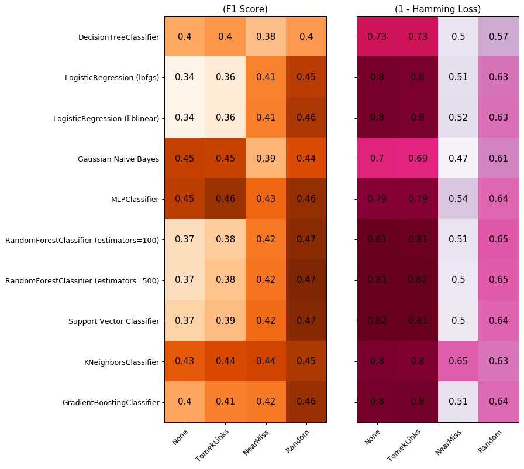

```python
show_evaluation_graph(gs_br)
```

```python
# Print details
print("Best parameters set found on development set:")
display(gs_br.best_params_)

print("\n\nScore found on Best parameters:")
display(gs_br.best_score_)
```

```
Best parameters set found on development set:
```

```
{'classifier': RandomForestClassifier(bootstrap=True, ccp_alpha=0.0, class_weight=None,
                        criterion='gini', max_depth=None, max_features='auto',
                        max_leaf_nodes=None, max_samples=None,
                        min_impurity_decrease=0.0, min_impurity_split=None,
                        min_samples_leaf=1, min_samples_split=2,
                        min_weight_fraction_leaf=0.0, n_estimators=500,
                        n_jobs=None, oob_score=False, random_state=None,
                        verbose=0, warm_start=False),
 'undersampler': RandomUnderSampler(random_state=None, replacement=False,
                    sampling_strategy='auto')}
```

```
Score found on Best parameters:
```

```
0.47341008257315326
```

### Evaluation Experiment Part 3:

Evaluate the best model on the test set

```python
print("Macro averaged f1 score on test set using best parameters is\n")
model = BinaryRelevanceClassifier(**gs_br.best_params_)
model.fit(X_train, y_train)
predictions = model.predict(X_test)
f1 = f1_score(y_test, predictions, average='macro')
print(f1)
resultDF = pd.DataFrame()
resultDF["Binary Relevance"] = pd.Series({'f1_score':f1})
```

```
Macro averaged f1 score on test set using best parameters is

0.4578885928603143
```

## Task 4: Implement the Classifier Chains Algorithm

```python
class ClassifierChains(BaseEstimator, ClassifierMixin):
    """The ClassifierChains is an algorithm that uses a
    homogenous ensemble of models to predict multi-output labels.
    It uses a One-vs-All approach to train the first model. Then,
    the output of this model is provided as an input to the next
    model. This process is repeated for all subsequent models.

    Parameters
    ----------
    classifier: (sklearn classifier), optional (default = DecisionTreeClassifier(criterion='entropy'))
    What classifier to use internally

    undersampler: (imblearn undersampler), optional (default = None)
    What imblearn based undersampling technique to use

    """
    def __init__(self, classifier=None, undersampler=None):

        # Check if it is a valid classifier
        if classifier is None:
            self.classifier = DecisionTreeClassifier(criterion='entropy')
        elif is_classifier(classifier):
            self.classifier = classifier
        else:
            raise ValueError("'classifier' needs to be an sklearn Classifier")

        # Check if it is a valid imblearn undersampler
        if undersampler is None:
            self.undersampler = None
        elif hasattr(undersampler, '_sampling_type') and undersampler._sampling_type in ['under-sampling', 'clean-sampling']:
            self.undersampler = undersampler
        else:
            raise ValueError("'undersampler' needs to be an imblearn undersampler")

    def fit(self, X, y):
        # Check that X and y have correct shape
        X, y = check_X_y(X, y, multi_output=True)
        # Ensure that target y is of a non-regression type
        check_classification_targets(y)

        self.number_of_output_classes = y.shape[1]

        # Randomly ordering the target labels
        self.y_order = list(range(self.number_of_output_classes))
        random.shuffle(self.y_order)

        # Train the ensemble of models
        self.models = [None for _ in range(self.number_of_output_classes)]

        data = X
        for index in self.y_order:
            # Separate the target data
            target = y[:,index]

            # Initialise and fit the model
            m = estimator_clone(self.classifier)

            if self.undersampler is not None:
                # Undersampling the data according to the target labels
                sampled_X, sampled_y = self.undersampler.fit_resample(data, target)
                m.fit(sampled_X, sampled_y)
            else:
                m.fit(data, target)

            self.models[index] = m

            # Append the target column of this iteration to the data set
            data = np.hstack([data, np.array([target]).T])

        return self

    def predict(self, X):
        # Check if fit had been called
        check_is_fitted(self, ['number_of_output_classes', 'models', 'y_order'])

        # Check that the input features match the type and shape of the training features
        X = check_array(X)

        # Predict using the ensemble of trained models
        predictions = [None for _ in range(self.number_of_output_classes)]

        data = X
        for index in self.y_order:
            y_pred = self.models[index].predict(data)
            predictions[index] = y_pred

            # Append the predicted column of this iteration to the data set
            data = np.hstack([data, np.array([y_pred]).T])

        return np.array(predictions).T

    def predict_proba(self, X):
        # Check if fit had been called
        check_is_fitted(self, ['number_of_output_classes', 'models', 'y_order'])

        # Check that the input features match the type and shape of the training features
        X = check_array(X)

        # Generate prediction probabilities using the ensemble of trained models
        pred_probas = [None for _ in range(self.number_of_output_classes)]

        data = X
        for index in self.y_order:
            pred_prob = self.models[index].predict_proba(data)
            pred_probas[index] = pred_prob

            # Generate the prediction
            y_pred = self.models[index].predict(data)

            # Append the predicted column of this iteration to the data set
            data = np.hstack([data, np.array([y_pred]).T])

        # Fixing the shape of pred_probas array
        pred_probas = np.stack(pred_probas, axis=1)

        return pred_probas
```

#### Check implementation of ClassifierChains

```python
model = ClassifierChains()
model.fit(X_train, y_train)
```

```
ClassifierChains(classifier=DecisionTreeClassifier(ccp_alpha=0.0,
                                                   class_weight=None,
                                                   criterion='entropy',
                                                   max_depth=None,
                                                   max_features=None,
                                                   max_leaf_nodes=None,
                                                   min_impurity_decrease=0.0,
                                                   min_impurity_split=None,
                                                   min_samples_leaf=1,
                                                   min_samples_split=2,
                                                   min_weight_fraction_leaf=0.0,
                                                   presort='deprecated',
                                                   random_state=None,
                                                   splitter='best'),
                 undersampler=None)
```

#### Predict and verify shape

```python
predictions = model.predict(X_test)
predictions.shape
```

```
(726, 14)
```

#### Get the macro-averaged F1 score

```python
f1 = f1_score(y_test, predictions, average='macro')
f1
```

```
0.39390028264428756
```

#### Get predict probabilities and verify shape

```python
pred_proba = model.predict_proba(X_test)
pred_proba.shape
```

```
(726, 14, 2)
```

## Task 5: Evaluate the Performance of the Classifier Chains Algorithm

### Evaluation Experiment Part 1:

Using the training data, perform a Grid Search (with cross validation) on various base classifiers and undersampling techniques

```python
gs_cc = GridSearchCV(ClassifierChains(), param_grid, cv=cross_val_folds, verbose = 2, scoring=scoring,
                                                refit='f1_score', n_jobs=-1, return_train_score=True)
```

```python
gs_cc.fit(X_train, y_train)
pass
```

```
Fitting 10 folds for each of 40 candidates, totalling 400 fits
```

```
[Parallel(n_jobs=-1)]: Using backend LokyBackend with 12 concurrent workers.
[Parallel(n_jobs=-1)]: Done  17 tasks      | elapsed:   10.6s
[Parallel(n_jobs=-1)]: Done 138 tasks      | elapsed:   46.2s
[Parallel(n_jobs=-1)]: Done 341 tasks      | elapsed: 12.8min
[Parallel(n_jobs=-1)]: Done 400 out of 400 | elapsed: 16.9min finished
```

### Evaluation Experiment Part 2:

Visualise the performance on various candidates with Macro averaged F1 score and (1 - hamming loss)

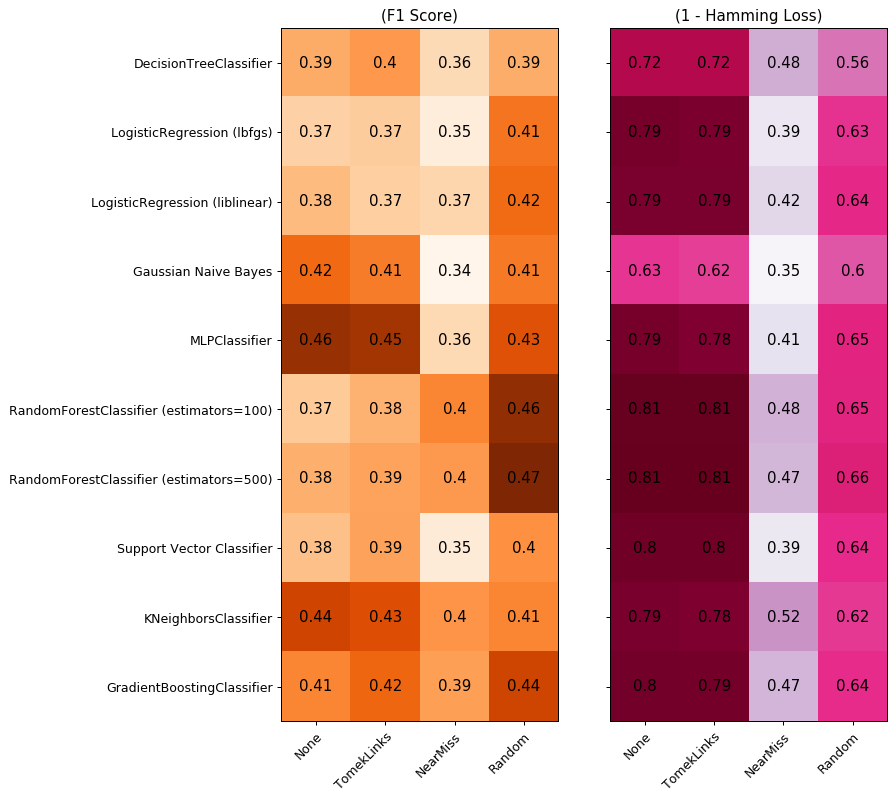

```python
show_evaluation_graph(gs_cc)
```

```python
# Print details
print("Best parameters set found on development set:")
display(gs_cc.best_params_)

print("\n\nScore found on Best parameters:")
display(gs_cc.best_score_)
```

```
Best parameters set found on development set:
```

```
{'classifier': RandomForestClassifier(bootstrap=True, ccp_alpha=0.0, class_weight=None,
                        criterion='gini', max_depth=None, max_features='auto',
                        max_leaf_nodes=None, max_samples=None,
                        min_impurity_decrease=0.0, min_impurity_split=None,
                        min_samples_leaf=1, min_samples_split=2,
                        min_weight_fraction_leaf=0.0, n_estimators=500,
                        n_jobs=None, oob_score=False, random_state=None,
                        verbose=0, warm_start=False),
 'undersampler': RandomUnderSampler(random_state=None, replacement=False,
                    sampling_strategy='auto')}
```

```
Score found on Best parameters:
```

```
0.4677585739580607
```

### Evaluation Experiment Part 3:

Evaluate the best model on the test set

```python
print("Macro averaged f1 score on test set using best parameters is\n")
model = ClassifierChains(**gs_cc.best_params_)
model.fit(X_train, y_train)
predictions = model.predict(X_test)
f1 = f1_score(y_test, predictions, average='macro')
resultDF["Classifier Chains"] = pd.Series({'f1_score':f1})
print(f1)
```

```
Macro averaged f1 score on test set using best parameters is

0.44334155296654804
```

### Performance Comparision:

This graph shows the comparision between Binary Relevance Classifier and Classifier Chains on the basis of `macro averaged f1 score` using best parameters found in the respective grid search.

Benchmarks added as per `"Benchmarking multi-label classification algorithms" (Pakrashi, Greene and MacNamee, 2016)`

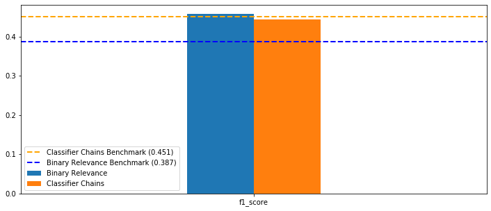

```python
ax = resultDF.plot.bar(rot=0, figsize=(12,5),width=0.2)
plt.axhline(y=0.451, linestyle='dashed', linewidth=2, color='orange', label='Classifier Chains Benchmark (0.451)')
plt.axhline(y=0.387, linestyle='dashed', linewidth=2, color='blue', label='Binary Relevance Benchmark (0.387)')
plt.legend(title=None)
plt.show()
```

## Task 6: Reflect on the Performance of the Different Models Evaluated

The evaluation measure should be dependent on the problem being solved. To evaluate performance in multi label classification, we can use measures like exact matching, hamming loss or macro-averaged F1 score. Exact matching considers the entire set of predicted labels for a given sample to be incorrect if it does not entirely match the true set. Hamming loss is a slightly loose measure as it penalises only the individual labels. However for imbalanced problems, accuracy is a problematic metric and in order to be able to account for the class imbalance, we used the macro-averaged F1 score as our primary evaluation measure.

For our evaluation experiment, we have split the data into train and test sets. We have used the training set to perform a Grid Search with cross validation to choose the best base classifier and undersampling technique. In order to utilise maximum amount of data for training, we decided to use cross validation. Once chosen, we retrained the model with best parameters and evaluated the model on the test set.

The BinaryRelevance and ClassifierChain algorithms have the complexity of the base model chosen multiplied by the number of labels to be classified.

Since classifier chains are highly susceptible to the order of labels chosen, in order to figure out an optimum label order, we tried:

- Random Shuffling
- Based on pairwise correlation using Pearson, Kendall Tau and Spearman rank correlation coefficients.
- Based on individual model accuracies in Binary Relevance classifier.
- A self implemented algorithm based on Quick Sorting Algorithm

We observed that Random Shuffling worked best and thus we included it in the ClassifierChain class implementation. We have not included other techniques in the notebook.